# Assignment 16: Writing a function - Loop

*How to do it?*:

- Open the Rmarkdown file of this assignment (link) in Rstudio.
- Right under each **question**, insert a code chunk (you can use the hotkey `Ctrl + Alt + I` to add a code chunk) and code the solution for the question.
- `Knit` the rmarkdown file (hotkey: `Ctrl + Alt + K`) to export an html.
- Publish the html file to your Githiub Page.

*Submission*: Submit the link on Github of the assignment to Canvas

1. Write the following function. Give examples to test your function.
- Input: a data frame
- Output: a data frame with all the missing of numeric variables replaced by the associated means.

Hint: [Similar function](https://bryantstats.github.io/math421/gganimate/18_writing_functions.html#28)

```r
mean_impute <- function(x)
{
  if(is.numeric(x))
  {
    # Find the mode of x
    mean_x <- mean(x)
    # Replace the missing by the mode
    library(tidyr)
    x <- replace_na(x, mean_x)
  }
return(x)
}

library(tidyverse)
numeric_impute <- function(d)
{
  for (i in 1:length(d))
  {if (is.numeric(d[[i]])) {
     d[[i]] <- mean_impute(d[[i]])
  }
  }
  return(d)
}
df <- read_csv('train.csv')
df <- numeric_impute(df$Fare)
sum(is.na(df))
```

```
## [1] 0
```

2. Write the following function. Give examples to test your function.
- Input: a data frame
- Output: a data frame with all the missing of variables replaced by the associated means (for numeric variables) or modes (for non-numeric variables).

Hint: Use If-statement to combine the function in Problem 1 and the function in [this example](https://bryantstats.github.io/math421/gganimate/18_writing_functions.html#28)

```r
mean_impute <- function(x)
{
  if(is.numeric(x))
  {
    # Find the mode of x
    mean_x <- mean(x)
    # Replace the missing by the mode
    library(tidyr)
    x <- replace_na(x, mean_x)
  }
return(x)
}

mode_impute <- function(x)
{
  if(!is.numeric(x))
  {
    # Find the mode of x
    mode_of_x <- names(sort(-table(x)))[1]
    # Replace the missing by the mode
    library(tidyr)
    x <- replace_na(x, mode_of_x)
  }
return(x)
}

library(tidyverse)

numeric_impute <- function(d)
{
  for (i in 1:length(d))
  {if (is.numeric(d[[i]])) {
     d[[i]] <- mean_impute(d[[i]])
  }  else{
       d[[i]] <- mode_impute(d[[i]])
  }
  }
  return(d)
}
df <- read_csv('train.csv')
df <- numeric_impute(df)
sum(is.na(df))
```

```
## [1] 177
```

3. Write the following function. Give examples to test your function.
- Input: a data frame
- Output: Bar plots of all non-numeric variables

Hint: [Similar function](https://bryantstats.github.io/math421/gganimate/18_writing_functions.html#33)

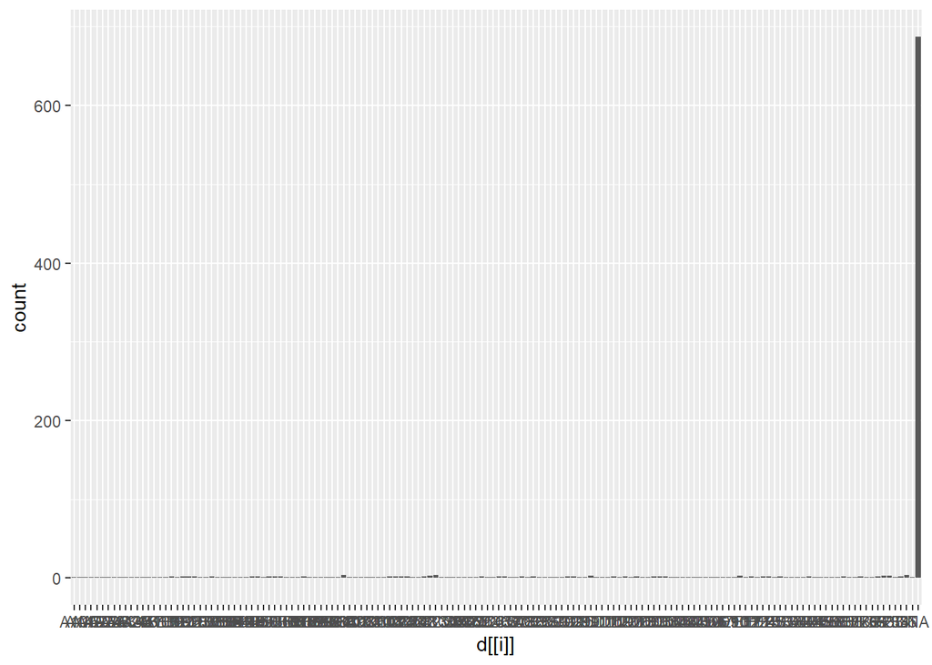

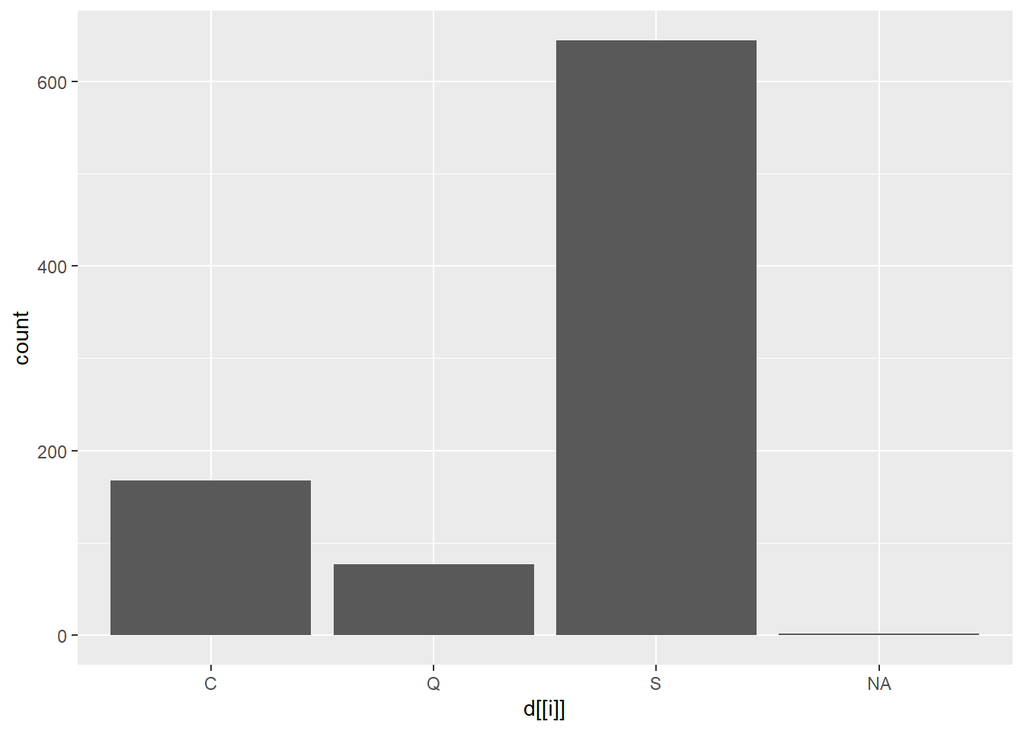

```r
library(ggplot2)
graph <- function(d)
{
  for (i in 1:length(d))
  {if (is.numeric(d[[i]])) {
  d[[i]] <- mean_impute(d[[i]])
  }  else{
    print(ggplot()+geom_bar(mapping = aes(x = d[[i]])))
  }
  }
  return(d)
}
df <- read_csv('train.csv')
df <- graph(df)
```

4. Write the following function. Give examples to test your function.
- Input: a data frame
- Output: all possible the bar plots of a non-numeric variable filled by a non-numeric variable.

Hint: [Similar function](https://bryantstats.github.io/math421/gganimate/18_writing_functions.html#40)

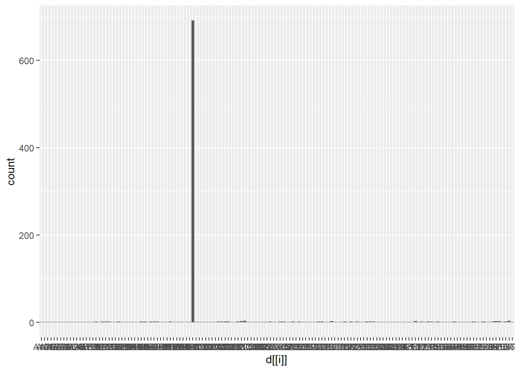

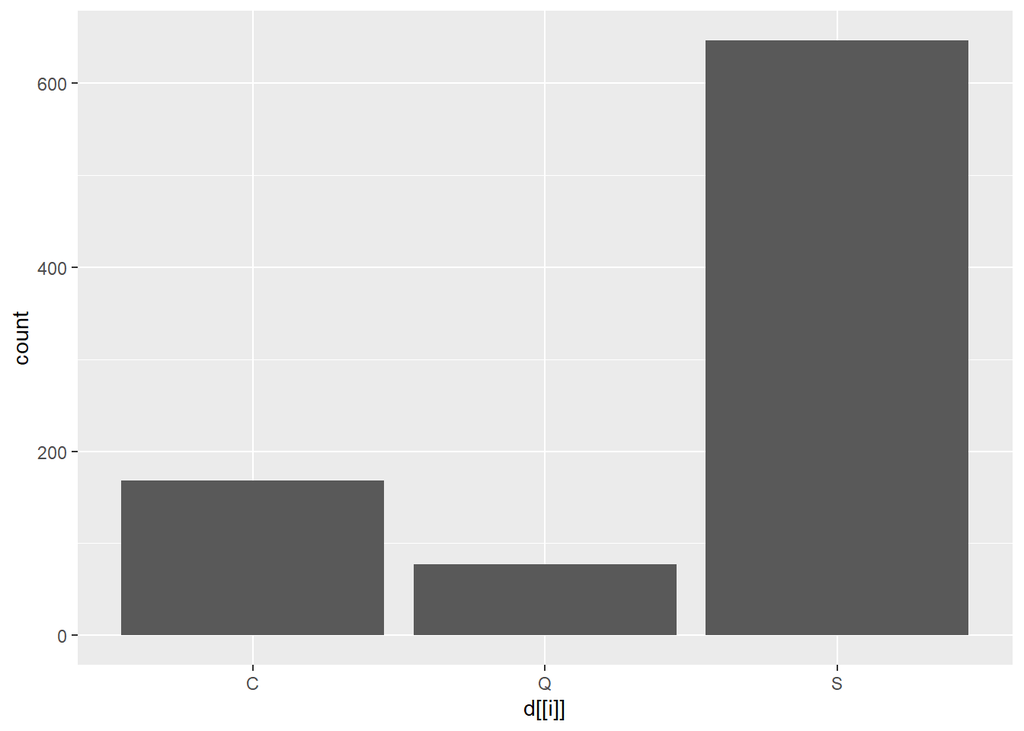

```r
df <- read_csv('train.csv')
df <- numeric_impute(df)
df <- graph(df)
```

5. Write the following function. Give examples to test your function.
- Input: a data frame
- Output:
  - all possible the bar plots of a non-numeric variable filled by a non-numeric variable.
  - all possible the density plots of a numeric variable colored by a non-numeric variable
  - all possible the scatter plots.

Hint: Combine [this function](https://bryantstats.github.io/math421/gganimate/18_writing_functions.html#37), [this function](https://bryantstats.github.io/math421/gganimate/18_writing_functions.html#40), and the function in Question 4. One way to combine is creating a new function, `quick_plot`, and call these three functions within `quic_kplot`.

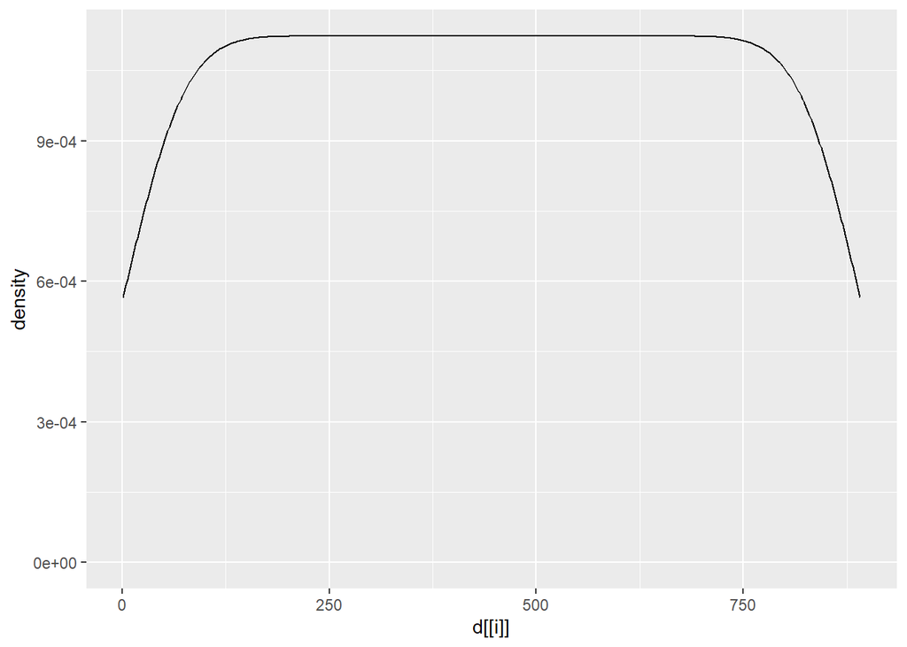

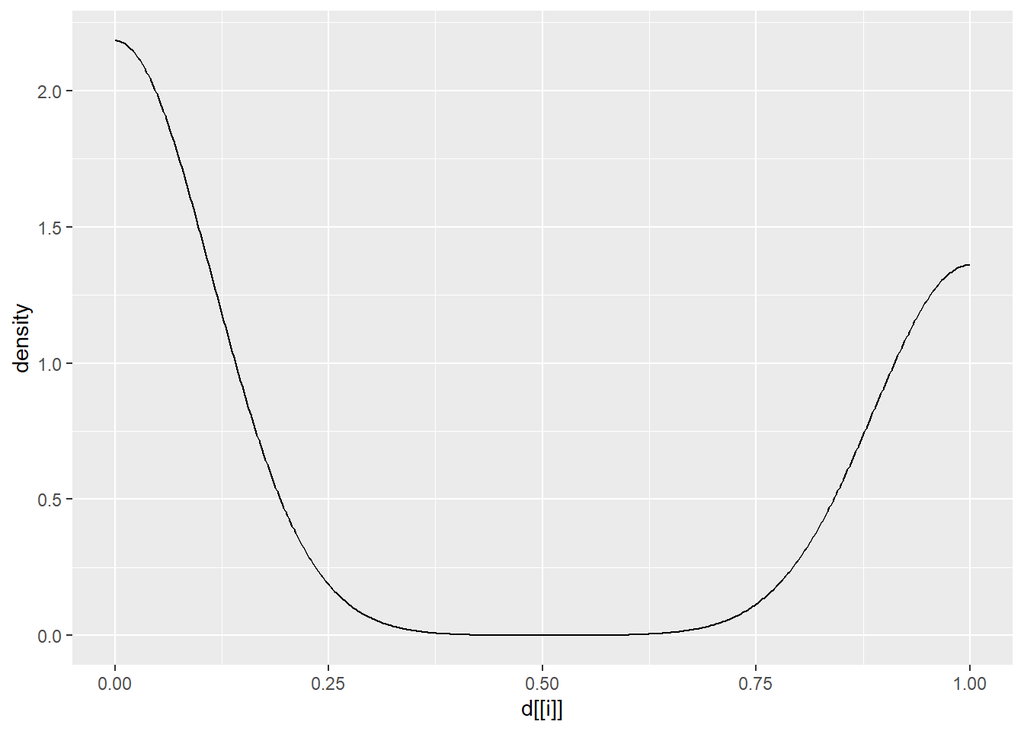

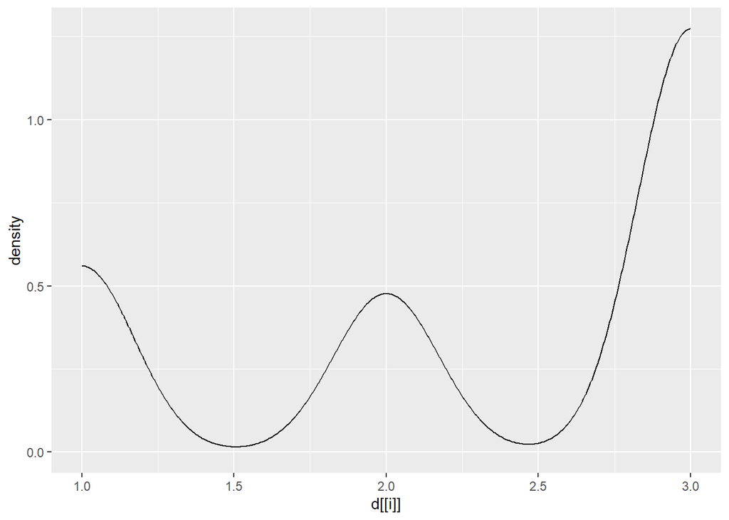

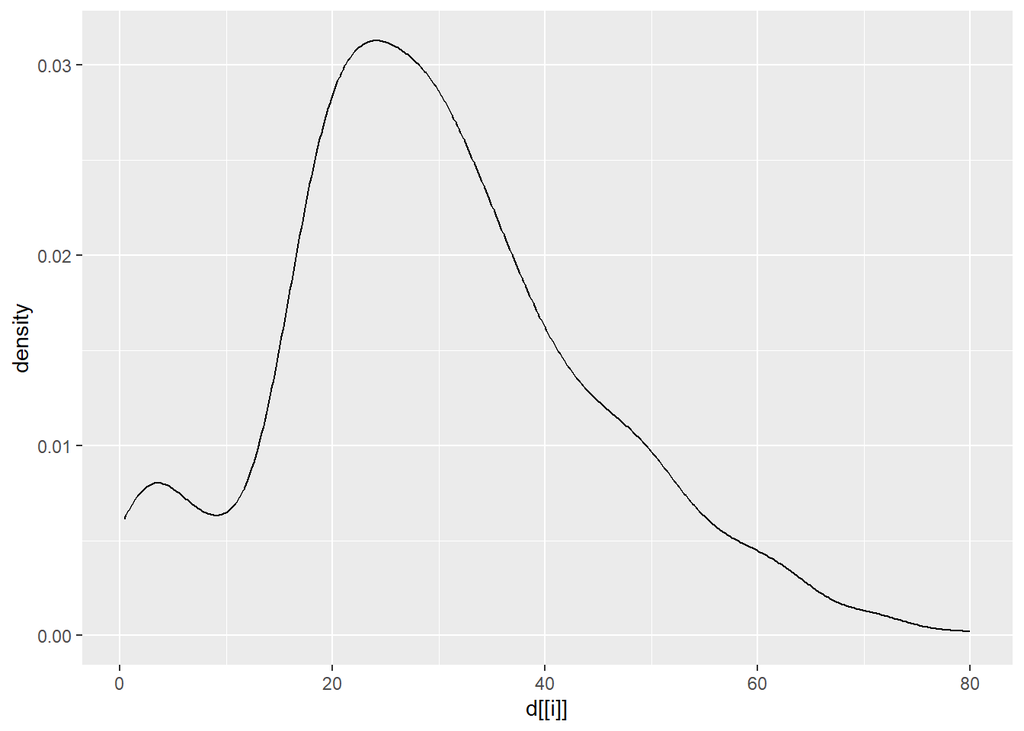

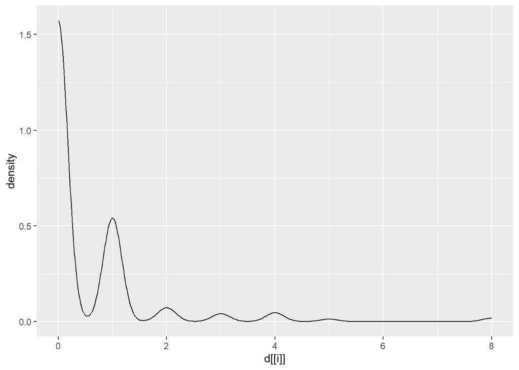

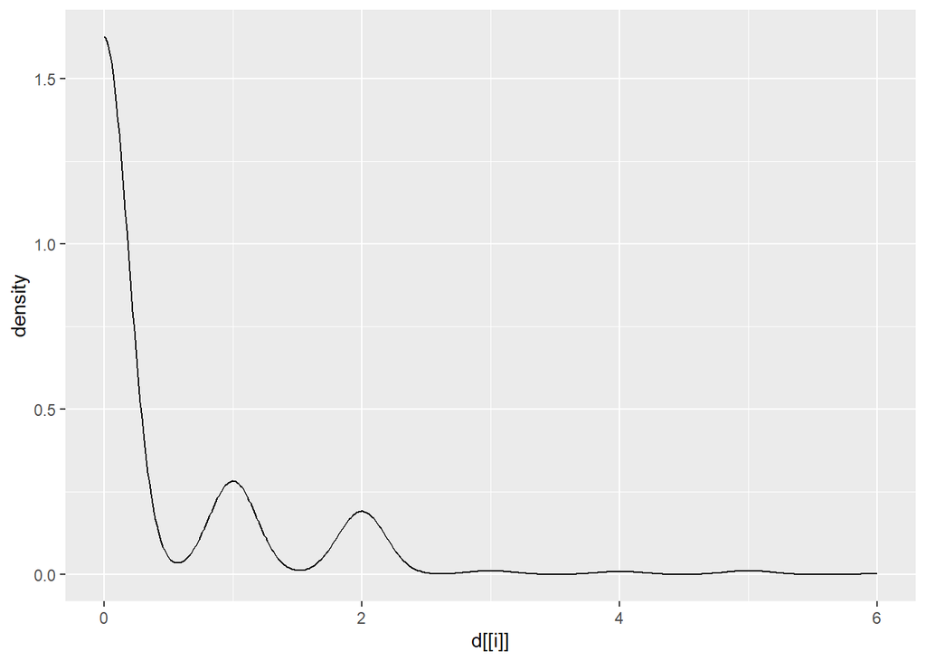

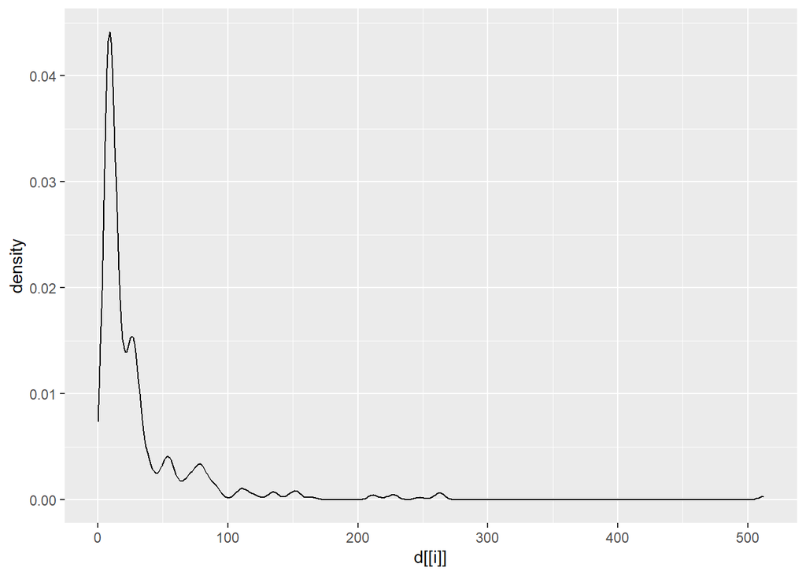

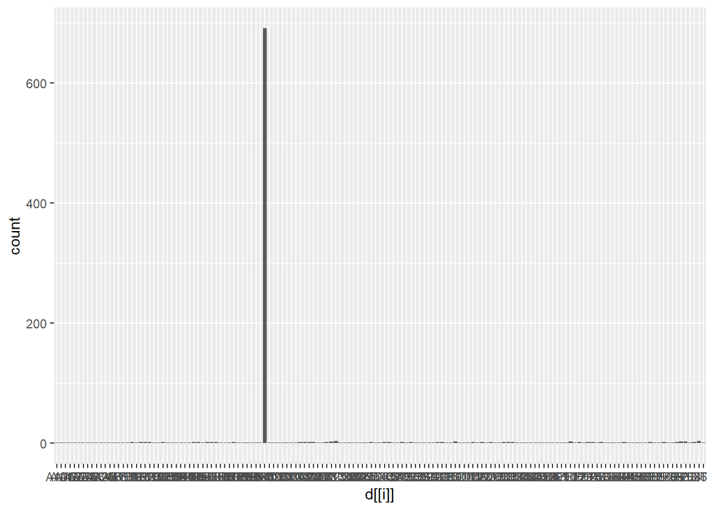

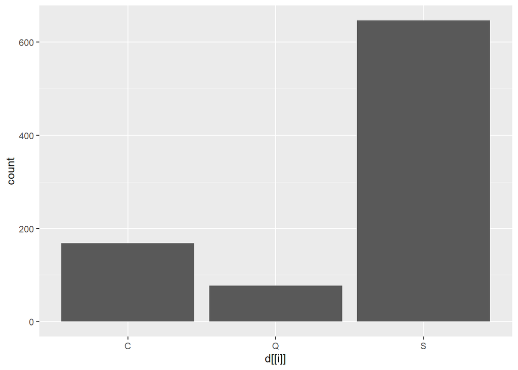

```r
library(ggplot2)
graph <- function(d)
{
  for (i in 1:length(d))
  {if (is.numeric(d[[i]])) {
  print(ggplot()+geom_density(mapping = aes(x = d[[i]])))
  }  else{
    print(ggplot()+geom_bar(mapping = aes(x = d[[i]])))
  }
  }
  return(d)
}
df <- read_csv('train.csv')
df <- numeric_impute(df)
df <- graph(df)
```

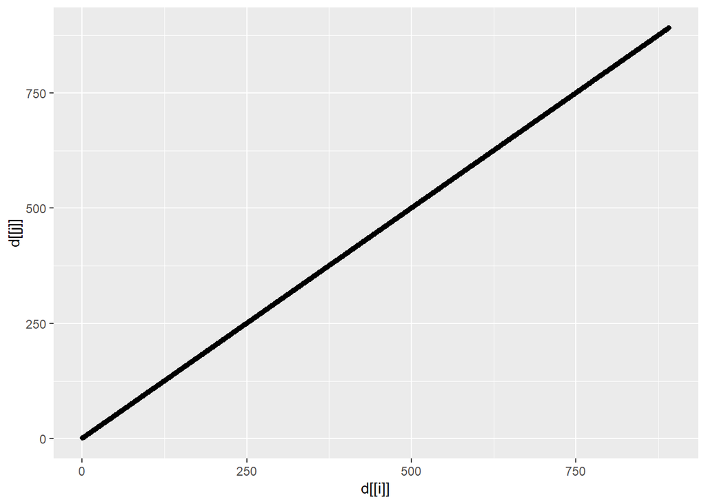

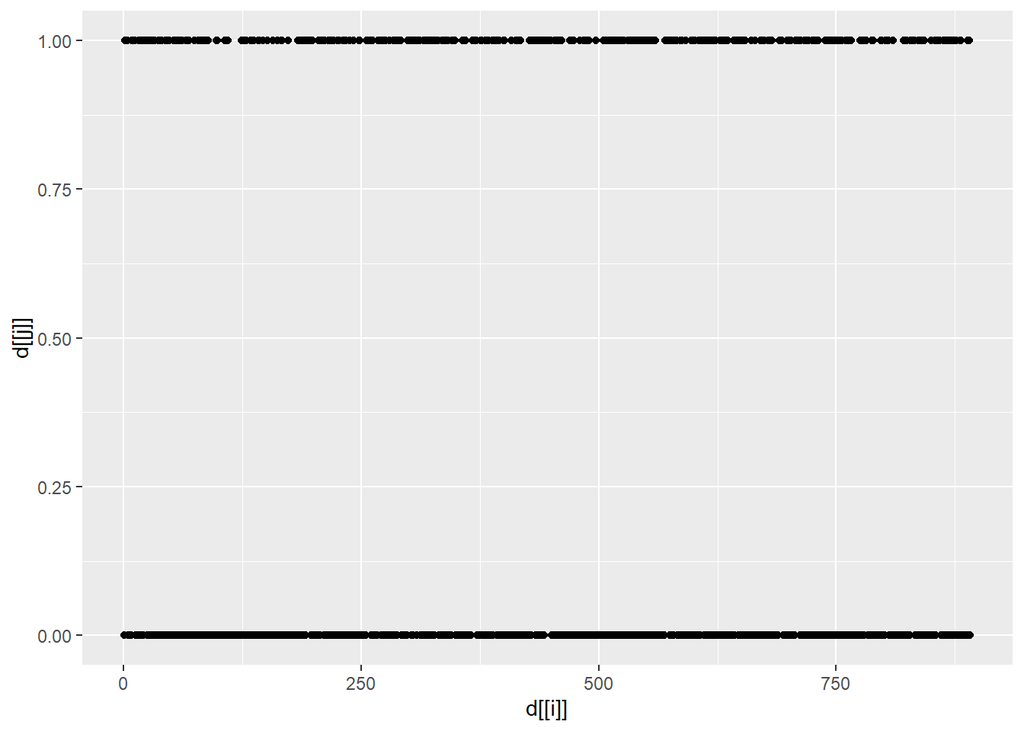

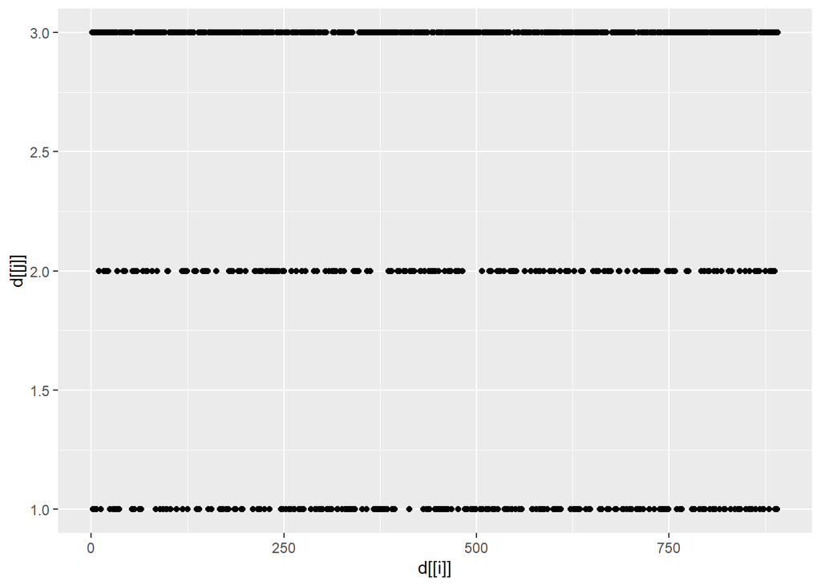

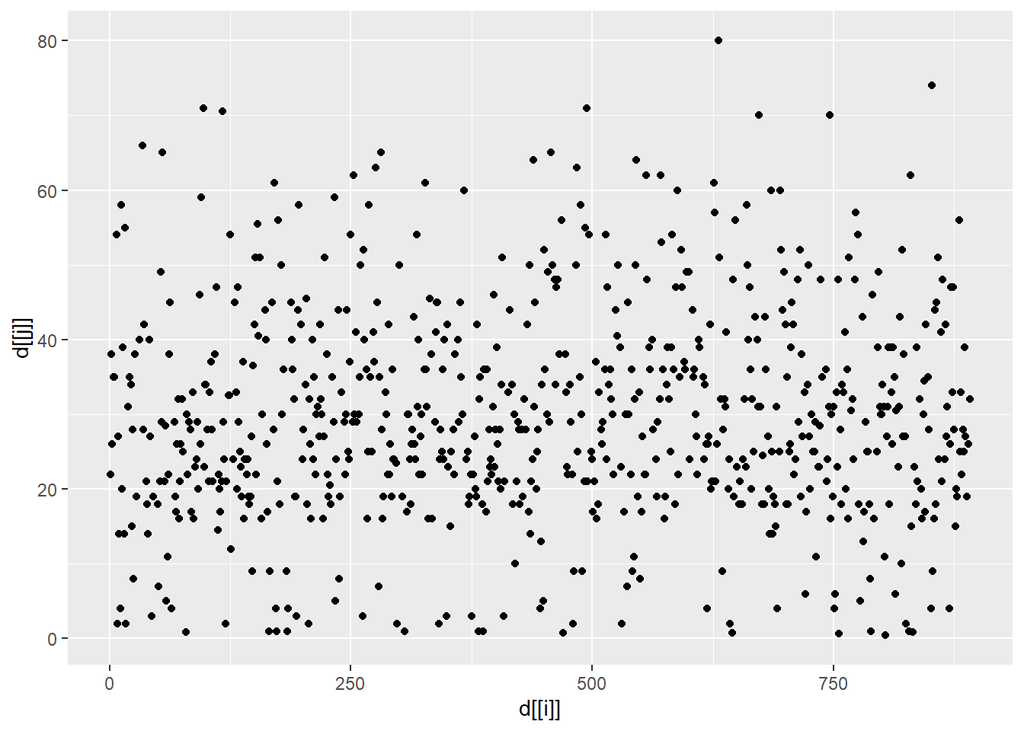

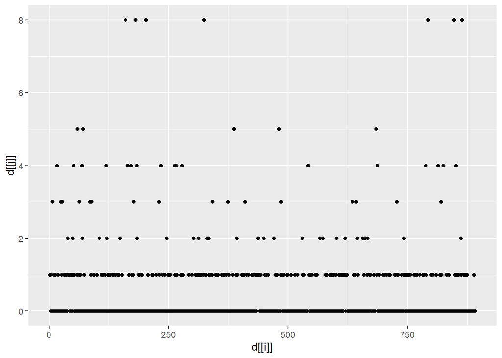

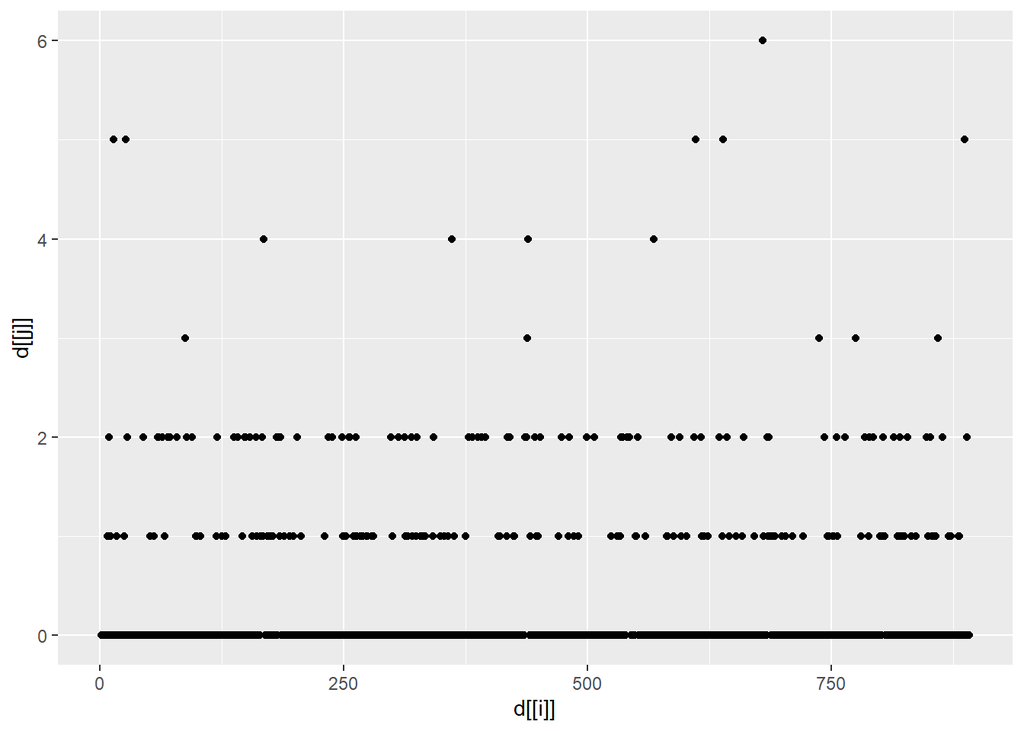

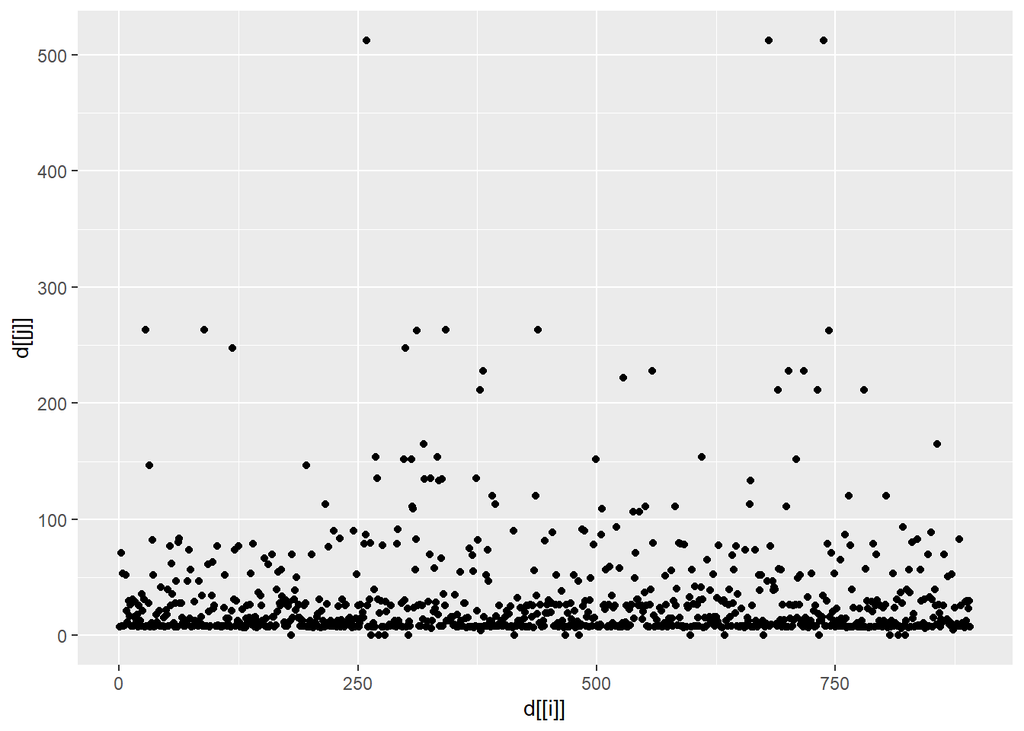

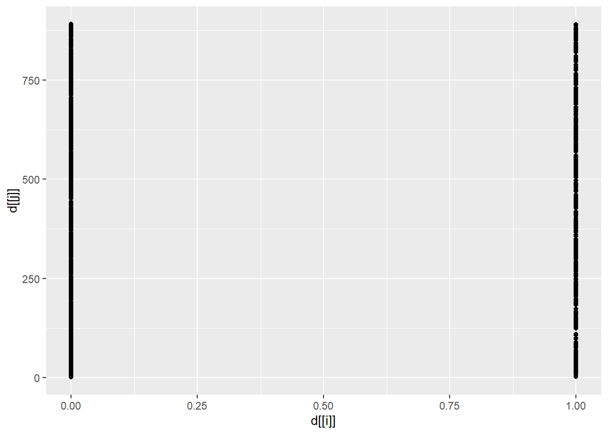

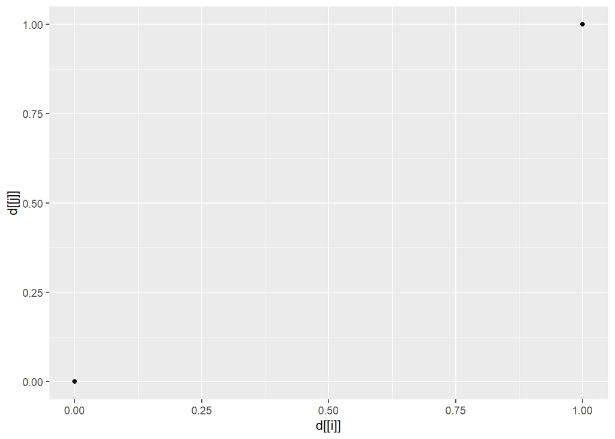

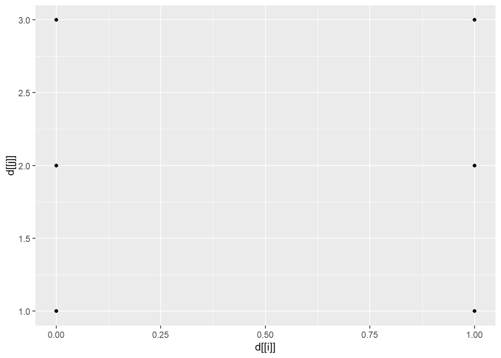

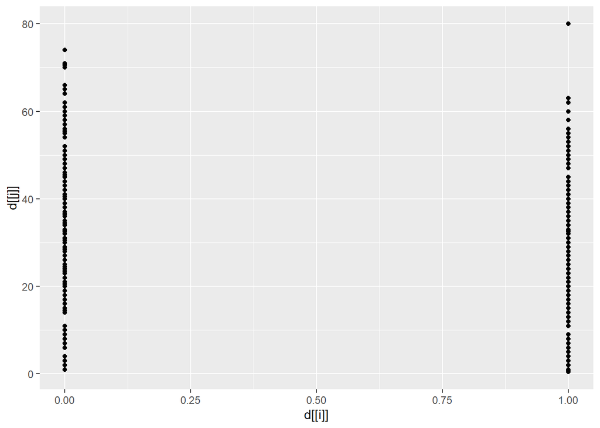

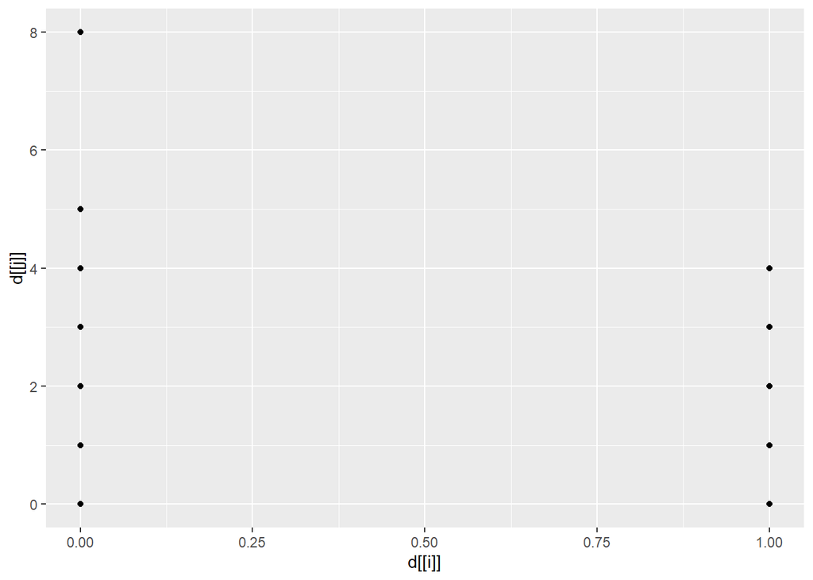

[37 more figures not shown]

```
## # A tibble: 891 x 12
##    PassengerId Survived Pclass Name   Sex     Age SibSp Parch Ticket  Fare Cabin
##          <dbl>    <dbl>  <dbl> <chr>  <chr> <dbl> <dbl> <dbl> <chr>  <dbl> <chr>
##  1           1        0      3 Braun~ male     22     1     0 A/5 2~  7.25 B96 ~
##  2           2        1      1 Cumin~ fema~    38     1     0 PC 17~ 71.3  C85
##  3           3        1      3 Heikk~ fema~    26     0     0 STON/~  7.92 B96 ~
##  4           4        1      1 Futre~ fema~    35     1     0 113803 53.1  C123
##  5           5        0      3 Allen~ male     35     0     0 373450  8.05 B96 ~
##  6           6        0      3 Moran~ male     NA     0     0 330877  8.46 B96 ~
##  7           7        0      1 McCar~ male     54     0     0 17463  51.9  E46
##  8           8        0      3 Palss~ male      2     3     1 349909 21.1  B96 ~
##  9           9        1      3 Johns~ fema~    27     0     2 347742 11.1  B96 ~
## 10          10        1      2 Nasse~ fema~    14     1     0 237736 30.1  B96 ~
## # ... with 881 more rows, and 1 more variable: Embarked <chr>
```

```r
SUPERGRAPH <- function(d)
{
  for (i in 1:length(d))
  {if (is.numeric(d[[i]])) {
    for (j in 1:length(d)) {
      if (is.numeric(d[[j]])) {
        print(ggplot()+geom_point(mapping = aes(x = d[[i]],y=d[[j]])))

      }
    }

  }

  }
  return(d)
}
SUPERGRAPH(df)
```